# Dolomedes minor male courtship - Data Analysis

CLEMOT Bastien

2023-05-02

```r
# Packages:
library(tidyverse)
library(Hmisc)
library(car)
library(lme4)
library(performance)
library(AICcmodavg)


# Datasets:
subset1 <- read.table("subset1_Bastien_original_weight.csv",sep=",",header=T)
subset2 <- read.table("subset2_Bastien_original_weight.csv",sep=",",header=T)
data <- rbind(subset1,subset2)
```

# Is male courtship changing depending on female mating state?

Differences between the two groups (virgin;mated) were assessed with three indicators of male courtship: total courtship duration, number of courtship segments, mean courtship segment length.

As all data were paired and, as a counting variable was used, it was decided to only use non-parametric test for paired data. Wilcoxon paired test were performed to assess differences between means. Differences between variance were also assessed by using a jackknife test.

### Jackknife function (Rothstein et William, 1981):

```r
# Used dataset should have 3 columns, first with female ID, second with variable for the first mating trial (virgin) and third with the variable in the second mating trial (mated).

# Function for the jackknife:
jackknife <- function(dataset) {
  # Calculate variance of variable X
  varX <- 0
  for (i in 1:nrow(dataset)) {
    varX <- varX + (dataset[i, 3] - mean(dataset[, 3])) ^ 2
  }
  # Calculate variance of variable Y
  varY <- 0
  for (i in 1:nrow(dataset)) {
    varY <- varY + (dataset[i, 2] - mean(dataset[, 2])) ^ 2
  }
  # Calculate y, ratio of variances
  y <- varY / varX
  # Calculate all y-i
  dataset$yi <- NA
  for (i in 1:nrow(dataset)) {
    varXi <- 0
    varYi <- 0
    dataseti <- dataset[-i, ]
    for (j in 1:(nrow(dataset) - 1)) {
      varXi <- varXi + (dataseti[j, 3] - mean(dataseti[, 3])) ^ 2
      varYi <- varYi + (dataseti[j, 2] - mean(dataseti[, 2])) ^ 2
    }
    dataset[i, 4] <- varYi / varXi
  }
  # Logarithmic transformation of all y-i
  dataset$Li <- nrow(dataset) * log(y) - (nrow(dataset) - 1) * log(dataset$yi)
  # Calculate mean of the distribution (mean of all y-i)
  meanL <- mean(dataset$Li)
  # Calculate variance of distribution (variance of all y-1)
  vLi <- 0
  for (i in 1:nrow(dataset)) {
    vLi <- vLi + (dataset[i, 5] - mean(dataset[, 5])) ^ 2
  }
  VarLi <- vLi / (nrow(dataset) * (nrow(dataset) - 1))
  # Calculate Q the statistical value
  Q <- meanL / sqrt(VarLi)
  return(Q)
}
```

## Total courtship duration:

```r
# Wilcoxon paired test:
wilcox.test(subset1$total.courtship.duration,subset2$total.courtship.duration,paired=TRUE)
```

```
##
##  Wilcoxon signed rank exact test
##
## data:  subset1$total.courtship.duration and subset2$total.courtship.duration
## V = 86, p-value = 0.1514
## alternative hypothesis: true location shift is not equal to 0
```

p-value > 0.05: no significant differences in mean between both groups.

```r
# Jackknife variance test:
dataset <- subset1[,c("Female","total.courtship.duration")]
colnames(dataset)[2] <- "virgin"
dataset <- left_join(dataset,subset2[,c("Female","total.courtship.duration")])
colnames(dataset)[3] <- "mated"
```

```r
jackknife(dataset)
```

```
## [1] -1.609057
```

Statistical value of -1.61 gives a p-value of 0.053 > 0.05: no significant differences in variance between two groups.

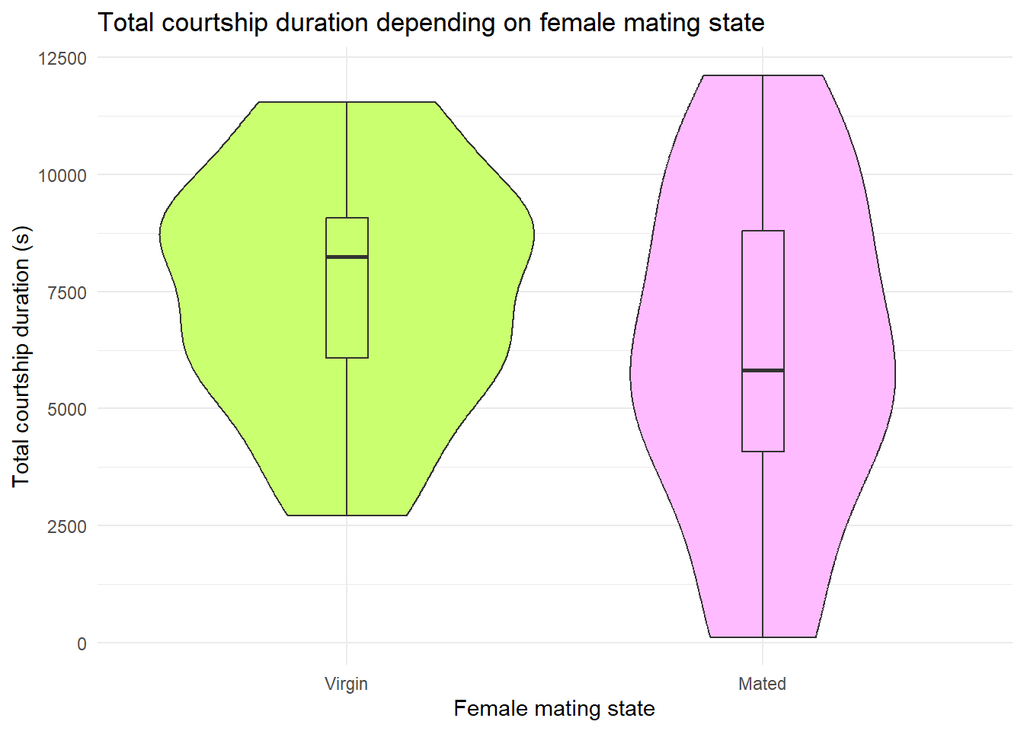

```r
# Graphical representation:
ggplot(data, aes(x=femalematedbefore, y=total.courtship.duration, fill=femalematedbefore)) +
  geom_violin() +
  geom_boxplot(width = 0.1) +
  scale_fill_manual(values=c("darkolivegreen1","#FFBBFF")) +
  xlab("Female mating state") +
  scale_x_discrete(labels = c("Virgin","Mated")) +
  ylab("Total courtship duration (s)") +
  ggtitle("Total courtship duration depending on female mating state") +
  theme_minimal() +
  theme(legend.position="none")
```

## Number of courtship segments:

```r
# Wilcoxon paired test:
wilcox.test(subset1$number.of.courtships,subset2$number.of.courtships,paired=TRUE)
```

```
##
##  Wilcoxon signed rank test with continuity correction
##
## data:  subset1$number.of.courtships and subset2$number.of.courtships
## V = 20.5, p-value = 0.1563
## alternative hypothesis: true location shift is not equal to 0
```

p-value > 0.05: no significant differences in mean between two groups.

```r
# Jackknife variance test:
dataset <- subset1[,c("Female","number.of.courtships")]
colnames(dataset)[2] <- "virgin"
dataset <- left_join(dataset,subset2[,c("Female","number.of.courtships")])
colnames(dataset)[3] <- "mated"
```

```r
jackknife(dataset)
```

```
## [1] -3.83757
```

Statistical value of -3.84 gives a p-value of 0.00006 <<< 0.05: significant difference of variance between two groups.

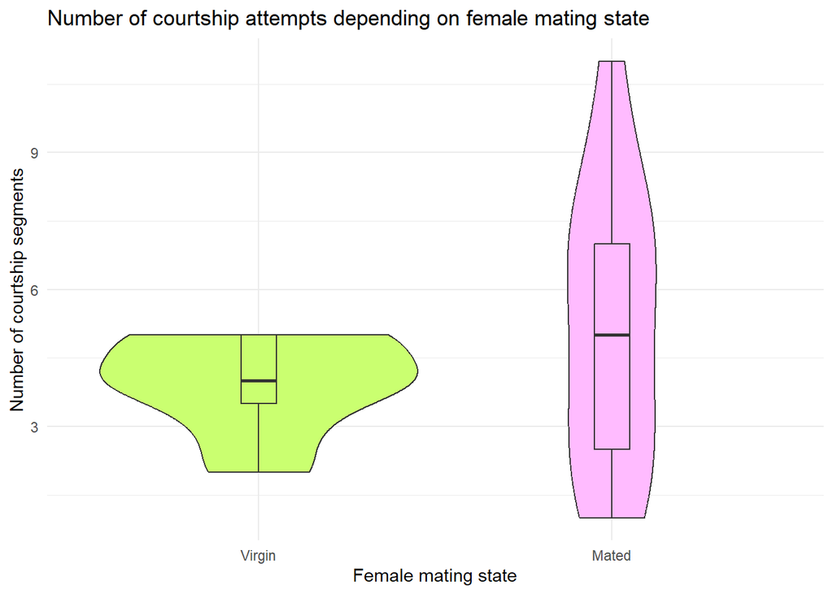

```r
# Graphical representation:
ggplot(data, aes(x=femalematedbefore, y=number.of.courtships, fill=femalematedbefore)) +
  geom_violin() +
  geom_boxplot(width = 0.1) +
  scale_fill_manual(values=c("darkolivegreen1","#FFBBFF")) +
  xlab("Female mating state") +
  scale_x_discrete(labels = c("Virgin","Mated")) +
  ylab("Number of courtship segments") +
  ggtitle("Number of courtship attempts depending on female mating state") +
  theme_minimal() +
  theme(legend.position="none")
```

## Mean courtship segment length:

```r
# Wilcoxon paired test:
wilcox.test(subset1$mean.courtship.length,subset2$mean.courtship.length,paired=TRUE)
```

```
##
##  Wilcoxon signed rank exact test
##
## data:  subset1$mean.courtship.length and subset2$mean.courtship.length
## V = 92, p-value = 0.073
## alternative hypothesis: true location shift is not equal to 0
```

p-value > 0.05: no significant differences in mean between two groups.

```r
# Jackknife variance test:
dataset <- subset1[,c("Female","mean.courtship.length")]
colnames(dataset)[2] <- "virgin"
dataset <- left_join(dataset,subset2[,c("Female","mean.courtship.length")])
colnames(dataset)[3] <- "mated"
```

```r
jackknife(dataset)
```

```
## [1] -0.614253
```

Statistical value of -0.61 give a p-value of 0.27 > 0.05: no significant differences in variance between two groups.

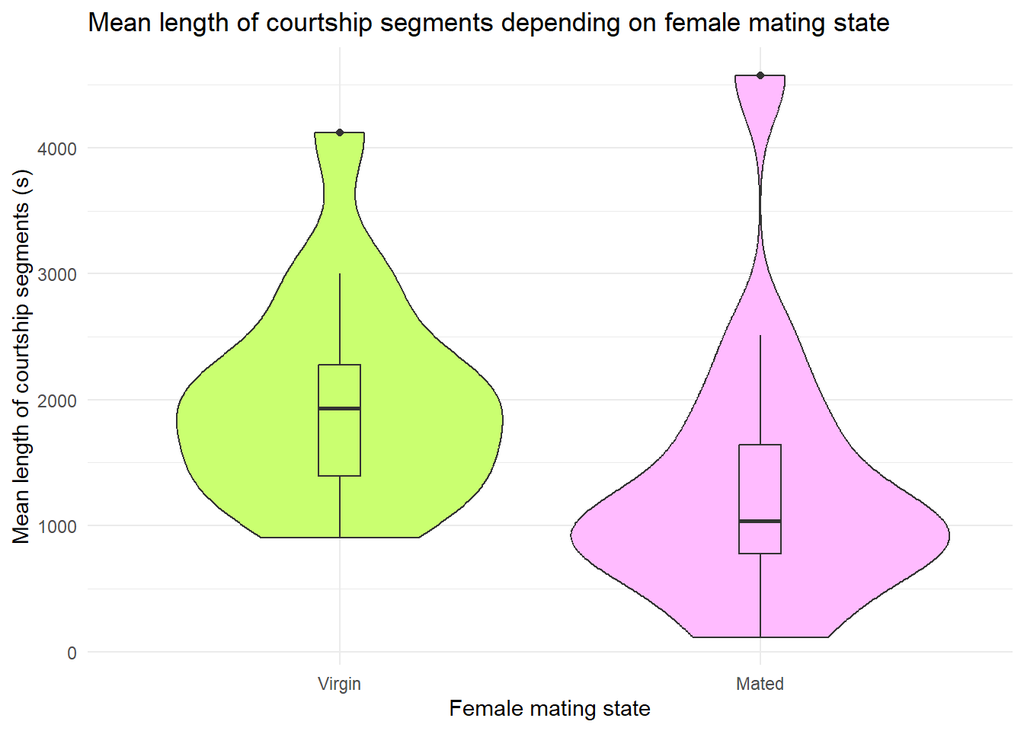

```r
# Graphical representation:
ggplot(data, aes(x=femalematedbefore, y=mean.courtship.length, fill=femalematedbefore)) +
  geom_violin() +
  geom_boxplot(width = 0.1) +
  scale_fill_manual(values=c("darkolivegreen1","#FFBBFF")) +
  xlab("Female mating state") +
  scale_x_discrete(labels = c("Virgin","Mated")) +
  ylab("Mean length of courtship segments (s)") +
  ggtitle("Mean length of courtship segments depending on female mating state") +
  theme_minimal() +
  theme(legend.position="none")
```

# As a trade-OFF between signals and behaviours that are used to increase male survival chances

To assess wich response to courtship should be investigated between all parameters, correlation test were performed.

Mixed model linear regression were performed between each quantitative parameter used to assess female aggressiveness and parameters used to assess male decisions in courtship and female mating state. Variance Inflation Factor was calculated to select pertinent explaining variables and AIC was calculated to select models. When performing mixed model linear regression, Female ID was used as a random effect and qualitative fixed effect were standardised to have the same scale.

For qualitative parameters, distribution McNemar’s chi square tests were performed with female mating state.

## Correlation tests between parameters:

```r
data$Male.killed <- data$pre.copulatory.kill | data$post.copulatory.kill
cor(data[,c("number.of.attacks","number.of.flees","Male.killed","latency.to.attack")],method = "spearman", use = "complete.obs")
```

```
##                   number.of.attacks number.of.flees Male.killed
## number.of.attacks        1.00000000      0.29624622 -0.04406051
## number.of.flees          0.29624622      1.00000000 -0.11009439
## Male.killed             -0.04406051     -0.11009439  1.00000000
## latency.to.attack       -0.49695893     -0.07338456 -0.24110987
##                   latency.to.attack
## number.of.attacks       -0.49695893
## number.of.flees         -0.07338456
## Male.killed             -0.24110987
## latency.to.attack        1.00000000
```

```r
cor.test(data$latency.to.attack,data$number.of.attacks,method = "spearman")
```

```
##
##  Spearman's rank correlation rho
##
## data:  data$latency.to.attack and data$number.of.attacks
## S = 2305.3, p-value = 0.02191
## alternative hypothesis: true rho is not equal to 0
## sample estimates:
##        rho
## -0.4969589
```

## Male getting killed:

```r
# Creation of contingency table:
Male.killed <- table(subset1$pre.copulatory.kill|subset1$post.copulatory.kill,subset2$pre.copulatory.kill|subset2$post.copulatory.kill,dnn=list("virgin","mated"))
Male.killed
```

```
##        mated
## virgin  FALSE TRUE
##   FALSE    11    1
##   TRUE      3    0
```

```r
# McNemar's chi square test:
mcnemar.test(Male.killed)
```

```
##
##  McNemar's Chi-squared test with continuity correction
##
## data:  Male.killed
## McNemar's chi-squared = 0.25, df = 1, p-value = 0.6171
```

p-value > 0.05: distribution is not significantly heterogeneous, males are not more often killed by virgin females than mated females

## Standardise data

```r
# Standardise data:
data$std.number.of.courtships <- scale(data$number.of.courtships,center=TRUE,scale=TRUE)
data$std.total.courtship.duration <- scale(data$total.courtship.duration,center=TRUE,scale=TRUE)
data$std.mean.courtship.length <- scale(data$mean.courtship.length,center=TRUE,scale=TRUE)
```

## Number of attacks:

```r
# Creation of model:
mod.attk <- glmer(number.of.attacks ~ femalematedbefore:std.number.of.courtships + femalematedbefore:std.total.courtship.duration + femalematedbefore:std.mean.courtship.length + (1|Female),family = poisson,data=data)
```

```
## boundary (singular) fit: see help('isSingular')
```

```r
summary(mod.attk)
```

```
## Generalized linear mixed model fit by maximum likelihood (Laplace
##   Approximation) [glmerMod]
##  Family: poisson  ( log )
## Formula: number.of.attacks ~ femalematedbefore:std.number.of.courtships +
##     femalematedbefore:std.total.courtship.duration + femalematedbefore:std.mean.courtship.length +
##     (1 | Female)
##    Data: data
##
##      AIC      BIC   logLik deviance df.resid
##     98.7    110.0    -41.4     82.7       22
##
## Scaled residuals:
##     Min      1Q  Median      3Q     Max
## -1.9053 -0.5776 -0.2096  0.6617  2.5101
##
## Random effects:
##  Groups Name        Variance Std.Dev.
##  Female (Intercept) 0        0
## Number of obs: 30, groups:  Female, 15
##
## Fixed effects:
##                                                     Estimate Std. Error z value
## (Intercept)                                          -0.3232     0.2854  -1.133
## femalematedbeforeFALSE:std.number.of.courtships      -2.8680     1.3857  -2.070
## femalematedbeforeTRUE:std.number.of.courtships        1.2568     0.2875   4.372
## femalematedbeforeFALSE:std.total.courtship.duration   1.6623     1.0362   1.604
## femalematedbeforeTRUE:std.total.courtship.duration   -0.4030     0.4137  -0.974
## femalematedbeforeFALSE:std.mean.courtship.length     -2.1248     1.1892  -1.787
## femalematedbeforeTRUE:std.mean.courtship.length       0.4664     0.5429   0.859
##                                                     Pr(>|z|)
## (Intercept)                                           0.2574
## femalematedbeforeFALSE:std.number.of.courtships       0.0385 *
## femalematedbeforeTRUE:std.number.of.courtships      1.23e-05 ***
## femalematedbeforeFALSE:std.total.courtship.duration   0.1087
## femalematedbeforeTRUE:std.total.courtship.duration    0.3300
## femalematedbeforeFALSE:std.mean.courtship.length      0.0740 .
## femalematedbeforeTRUE:std.mean.courtship.length       0.3903
## ---
## Signif. codes:  0 '***' 0.001 '**' 0.01 '*' 0.05 '.' 0.1 ' ' 1
##
```

[output cut: 9 more lines]

```
## fmlmtdbfrFALSE:std.n..
## fmlmtdbfrTRUE:std.n..
## fmlmtdbfrFALSE:std.t..
## fmlmtdbfrTRUE:std.t..   0.013
## fmlmtdbfrFALSE:std.m.. -0.952                 -0.012
## fmlmtdbfrTRUE:std.m..  -0.055                 -0.730
##                        fmlmtdbfrFALSE:std.m..
## fmlmtdbfrFALSE:std.n..
## fmlmtdbfrTRUE:std.n..
## fmlmtdbfrFALSE:std.t..
## fmlmtdbfrTRUE:std.t..
## fmlmtdbfrFALSE:std.m..
## fmlmtdbfrTRUE:std.m..   0.049
## optimizer (Nelder_Mead) convergence code: 0 (OK)
## boundary (singular) fit: see help('isSingular')
```

```r
# Obtain VIF:
vif(mod.attk)
```

```
##                                                    GVIF Df GVIF^(1/(2*Df))
## femalematedbefore:std.number.of.courtships     39.86171  2        2.512690
## femalematedbefore:std.total.courtship.duration 44.97308  2        2.589633
## femalematedbefore:std.mean.courtship.length    47.80410  2        2.629458
```

```r
# Find best model based on AIC:
AIC(glmer(number.of.attacks ~ femalematedbefore:std.number.of.courtships + femalematedbefore:std.total.courtship.duration + femalematedbefore:std.mean.courtship.length + (1|Female),family = poisson,data=data))
```

```
## boundary (singular) fit: see help('isSingular')
```

```
## [1] 98.74236
```

```r
AIC(glmer(number.of.attacks ~ femalematedbefore:std.total.courtship.duration + femalematedbefore:std.mean.courtship.length + (1|Female),family = poisson,data=data))
```

```
## [1] 109.7631
```

```r
AIC(glmer(number.of.attacks ~ femalematedbefore:std.number.of.courtships + femalematedbefore:std.mean.courtship.length + (1|Female),family = poisson,data=data))
```

```
## [1] 98.57017
```

```r
AIC(glmer(number.of.attacks ~ femalematedbefore:std.number.of.courtships + femalematedbefore:std.total.courtship.duration + (1|Female),family = poisson,data=data))
```

```
## [1] 99.67942
```

```r
AIC(glmer(number.of.attacks ~ femalematedbefore:std.mean.courtship.length + (1|Female),family = poisson,data=data))
```

```
## [1] 117.4793
```

```r
AIC(glmer(number.of.attacks ~ femalematedbefore:std.number.of.courtships + (1|Female),family = poisson,data=data))
```

```
## [1] 96.25482
```

```r
AIC(glmer(number.of.attacks ~ femalematedbefore:std.total.courtship.duration + (1|Female),family = poisson,data=data))
```

```
## [1] 116.3187
```

```r
AIC(glmer(number.of.attacks ~ 1 + (1|Female),family = poisson,data=data))
```

```
## [1] 121.6228
```

So we want to keep the 6th model, with only the number of courtships.

```r
# Keep the best model
mod.attk2 <- glmer(number.of.attacks ~ femalematedbefore:std.number.of.courtships + (1|Female),family = poisson,data=data)
summary(mod.attk2)
```

```
## Generalized linear mixed model fit by maximum likelihood (Laplace
##   Approximation) [glmerMod]
##  Family: poisson  ( log )
## Formula: number.of.attacks ~ femalematedbefore:std.number.of.courtships +
##     (1 | Female)
##    Data: data
##
##      AIC      BIC   logLik deviance df.resid
##     96.3    101.9    -44.1     88.3       26
##
## Scaled residuals:
##     Min      1Q  Median      3Q     Max
## -1.7223 -0.7392  0.1493  0.7405  1.7996
##
## Random effects:
##  Groups Name        Variance Std.Dev.
##  Female (Intercept) 0.04573  0.2138
## Number of obs: 30, groups:  Female, 15
##
## Fixed effects:
##                                                 Estimate Std. Error z value
## (Intercept)                                      -0.1088     0.2308  -0.471
## femalematedbeforeFALSE:std.number.of.courtships  -0.4982     0.5077  -0.981
## femalematedbeforeTRUE:std.number.of.courtships    0.8859     0.1555   5.698
##                                                 Pr(>|z|)
## (Intercept)                                        0.637
## femalematedbeforeFALSE:std.number.of.courtships    0.326
## femalematedbeforeTRUE:std.number.of.courtships  1.21e-08 ***
## ---
## Signif. codes:  0 '***' 0.001 '**' 0.01 '*' 0.05 '.' 0.1 ' ' 1
##
## Correlation of Fixed Effects:
##             (Intr) fFALSE
## fmFALSE:...  0.468
## fmlTRUE:... -0.599 -0.329
```

## Number of flees:

```r
# Creation of model:
mod.flees <- glmer(number.of.flees ~ femalematedbefore:std.number.of.courtships + femalematedbefore:std.total.courtship.duration + femalematedbefore:std.mean.courtship.length + (1|Female),family = poisson,data=data)
summary(mod.flees)
```

```
## Generalized linear mixed model fit by maximum likelihood (Laplace
##   Approximation) [glmerMod]
##  Family: poisson  ( log )
## Formula: number.of.flees ~ femalematedbefore:std.number.of.courtships +
##     femalematedbefore:std.total.courtship.duration + femalematedbefore:std.mean.courtship.length +
##     (1 | Female)
##    Data: data
##
##      AIC      BIC   logLik deviance df.resid
##    129.2    140.4    -56.6    113.2       22
##
## Scaled residuals:
##      Min       1Q   Median       3Q      Max
## -1.21634 -0.57960  0.07741  0.46321  0.85531
##
## Random effects:
##  Groups Name        Variance Std.Dev.
##  Female (Intercept) 0.3362   0.5799
## Number of obs: 30, groups:  Female, 15
##
## Fixed effects:
##                                                     Estimate Std. Error z value
## (Intercept)                                           0.7668     0.2415   3.175
## femalematedbeforeFALSE:std.number.of.courtships      -0.3066     1.0660  -0.288
## femalematedbeforeTRUE:std.number.of.courtships        0.1081     0.3371   0.321
## femalematedbeforeFALSE:std.total.courtship.duration   0.5199     0.6703   0.776
## femalematedbeforeTRUE:std.total.courtship.duration    0.5483     0.4022   1.363
## femalematedbeforeFALSE:std.mean.courtship.length     -0.7374     0.7579  -0.973
## femalematedbeforeTRUE:std.mean.courtship.length      -0.2813     0.3991  -0.705
##                                                     Pr(>|z|)
## (Intercept)                                           0.0015 **
## femalematedbeforeFALSE:std.number.of.courtships       0.7736
## femalematedbeforeTRUE:std.number.of.courtships        0.7485
## femalematedbeforeFALSE:std.total.courtship.duration   0.4380
## femalematedbeforeTRUE:std.total.courtship.duration    0.1728
## femalematedbeforeFALSE:std.mean.courtship.length      0.3306
## femalematedbeforeTRUE:std.mean.courtship.length       0.4809
## ---
## Signif. codes:  0 '***' 0.001 '**' 0.01 '*' 0.05 '.' 0.1 ' ' 1
##
## Correlation of Fixed Effects:
##                        (Intr) fmlmtdbfrFALSE:std.n.. fmlmtdbfrTRUE:std.n..
## fmlmtdbfrFALSE:std.n..  0.449
## fmlmtdbfrTRUE:std.n..  -0.241 -0.115
## fmlmtdbfrFALSE:std.t.. -0.429 -0.877                  0.064
## fmlmtdbfrTRUE:std.t..   0.032 -0.065                 -0.839
## fmlmtdbfrFALSE:std.m..  0.367  0.889                 -0.018
## fmlmtdbfrTRUE:std.m..   0.004  0.041                  0.788
##                        fmlmtdbfrFALSE:std.t.. fmlmtdbfrTRUE:std.t..
## fmlmtdbfrFALSE:std.n..
## fmlmtdbfrTRUE:std.n..
## fmlmtdbfrFALSE:std.t..
## fmlmtdbfrTRUE:std.t..   0.140
## fmlmtdbfrFALSE:std.m.. -0.915                 -0.128
## fmlmtdbfrTRUE:std.m..  -0.117                 -0.817
##                        fmlmtdbfrFALSE:std.m..
## fmlmtdbfrFALSE:std.n..
## fmlmtdbfrTRUE:std.n..
## fmlmtdbfrFALSE:std.t..
## fmlmtdbfrTRUE:std.t..
## fmlmtdbfrFALSE:std.m..
## fmlmtdbfrTRUE:std.m..   0.095
```

```r
# Obtain VIF:
vif(mod.flees)
```

```
##                                                    GVIF Df GVIF^(1/(2*Df))
## femalematedbefore:std.number.of.courtships     25.42897  2        2.245599
## femalematedbefore:std.total.courtship.duration 34.27412  2        2.419589
## femalematedbefore:std.mean.courtship.length    28.09505  2        2.302276
```

```r
# Find best model based on AIC:
AIC(glmer(number.of.flees ~ femalematedbefore:std.number.of.courtships + femalematedbefore:std.total.courtship.duration + femalematedbefore:std.mean.courtship.length + (1|Female),family = poisson,data=data))
```

```
## [1] 129.2086
```

```r
AIC(glmer(number.of.flees ~ femalematedbefore:std.total.courtship.duration + femalematedbefore:std.mean.courtship.length + (1|Female),family = poisson,data=data))
```

```
## [1] 125.377
```

```r
AIC(glmer(number.of.flees ~ femalematedbefore:std.number.of.courtships + femalematedbefore:std.mean.courtship.length + (1|Female),family = poisson,data=data))
```

```
## [1] 127.4369
```

```r
AIC(glmer(number.of.flees ~ femalematedbefore:std.number.of.courtships + femalematedbefore:std.total.courtship.duration + (1|Female),family = poisson,data=data))
```

```
## [1] 126.6258
```

```r
AIC(glmer(number.of.flees ~ femalematedbefore:std.mean.courtship.length + (1|Female),family = poisson,data=data))
```

```
## [1] 131.2533
```

```r
AIC(glmer(number.of.flees ~ femalematedbefore:std.number.of.courtships + (1|Female),family = poisson,data=data))
```

```
## [1] 124.3941
```

```r
AIC(glmer(number.of.flees ~ femalematedbefore:std.total.courtship.duration + (1|Female),family = poisson,data=data))
```

```
## [1] 127.7438
```

```r
AIC(glmer(number.of.flees ~ 1 + (1|Female),family = poisson,data=data))
```

```
## [1] 131.9183
```

We want to keep the 6th one

```r
mod.flees2 <- glmer(number.of.flees ~ femalematedbefore:std.number.of.courtships + (1|Female),family = poisson,data=data)
summary(mod.flees2)
```

```
## Generalized linear mixed model fit by maximum likelihood (Laplace
##   Approximation) [glmerMod]
##  Family: poisson  ( log )
## Formula: number.of.flees ~ femalematedbefore:std.number.of.courtships +
##     (1 | Female)
##    Data: data
##
##      AIC      BIC   logLik deviance df.resid
##    124.4    130.0    -58.2    116.4       26
##
## Scaled residuals:
##      Min       1Q   Median       3Q      Max
## -1.42840 -0.58281  0.08637  0.52379  1.14090
##
## Random effects:
##  Groups Name        Variance Std.Dev.
##  Female (Intercept) 0.3665   0.6054
## Number of obs: 30, groups:  Female, 15
##
## Fixed effects:
##                                                 Estimate Std. Error z value
## (Intercept)                                       0.7663     0.2226   3.443
## femalematedbeforeFALSE:std.number.of.courtships   0.5294     0.4414   1.199
## femalematedbeforeTRUE:std.number.of.courtships    0.4459     0.1577   2.827
##                                                 Pr(>|z|)
## (Intercept)                                     0.000575 ***
## femalematedbeforeFALSE:std.number.of.courtships 0.230402
## femalematedbeforeTRUE:std.number.of.courtships  0.004694 **
## ---
## Signif. codes:  0 '***' 0.001 '**' 0.01 '*' 0.05 '.' 0.1 ' ' 1
##
## Correlation of Fixed Effects:
##             (Intr) fFALSE
## fmFALSE:...  0.192
## fmlTRUE:... -0.344 -0.131
```

## Latency to attack:

```r
# Creation of model:
mod.lat.attk <- glmer(latency.to.attack ~ femalematedbefore:std.number.of.courtships + femalematedbefore:std.total.courtship.duration + femalematedbefore:std.mean.courtship.length + (1|Female),family = gaussian,data=data)
```

```
## boundary (singular) fit: see help('isSingular')
```

```r
summary(mod.lat.attk)
```

```
## Linear mixed model fit by REML ['lmerMod']
## Formula: latency.to.attack ~ femalematedbefore:std.number.of.courtships +
##     femalematedbefore:std.total.courtship.duration + femalematedbefore:std.mean.courtship.length +
##     (1 | Female)
##    Data: data
##
## REML criterion at convergence: 284.6
##
## Scaled residuals:
##      Min       1Q   Median       3Q      Max
## -1.52665 -0.53595 -0.09488  0.46716  1.49076
##
## Random effects:
##  Groups   Name        Variance Std.Dev.
##  Female   (Intercept)        0    0
##  Residual             18071115 4251
## Number of obs: 21, groups:  Female, 14
##
## Fixed effects:
##                                                     Estimate Std. Error t value
## (Intercept)                                             7812       1416   5.515
## femalematedbeforeFALSE:std.number.of.courtships         6047       8165   0.741
## femalematedbeforeTRUE:std.number.of.courtships         -2416       2228  -1.084
## femalematedbeforeFALSE:std.total.courtship.duration    -2889       6090  -0.474
## femalematedbeforeTRUE:std.total.courtship.duration      1549       3067   0.505
## femalematedbeforeFALSE:std.mean.courtship.length        4871       7581   0.643
## femalematedbeforeTRUE:std.mean.courtship.length        -1169       2342  -0.499
##
## Correlation of Fixed Effects:
##                        (Intr) fmlmtdbfrFALSE:std.n.. fmlmtdbfrTRUE:std.n..
## fmlmtdbfrFALSE:std.n..  0.698
## fmlmtdbfrTRUE:std.n..  -0.334 -0.233
## fmlmtdbfrFALSE:std.t.. -0.639 -0.932                  0.214
## fmlmtdbfrTRUE:std.t..   0.294  0.205                 -0.899
## fmlmtdbfrFALSE:std.m..  0.575  0.910                 -0.192
## fmlmtdbfrTRUE:std.m..  -0.135 -0.094                  0.811
##                        fmlmtdbfrFALSE:std.t.. fmlmtdbfrTRUE:std.t..
## fmlmtdbfrFALSE:std.n..
## fmlmtdbfrTRUE:std.n..
## fmlmtdbfrFALSE:std.t..
## fmlmtdbfrTRUE:std.t..  -0.188
## fmlmtdbfrFALSE:std.m.. -0.964                  0.169
## fmlmtdbfrTRUE:std.m..   0.086                 -0.874
##                        fmlmtdbfrFALSE:std.m..
## fmlmtdbfrFALSE:std.n..
## fmlmtdbfrTRUE:std.n..
## fmlmtdbfrFALSE:std.t..
## fmlmtdbfrTRUE:std.t..
## fmlmtdbfrFALSE:std.m..
## fmlmtdbfrTRUE:std.m..  -0.077
## optimizer (nloptwrap) convergence code: 0 (OK)
## boundary (singular) fit: see help('isSingular')
```

```r
# Obtain VIF:
vif(mod.lat.attk)
```

```
##                                                     GVIF Df GVIF^(1/(2*Df))
## femalematedbefore:std.number.of.courtships      40.06755  2        2.515928
## femalematedbefore:std.total.courtship.duration 142.52206  2        3.455179
## femalematedbefore:std.mean.courtship.length     64.63711  2        2.835440
```

So we want to remove the std.total.courtship.duration

```r
# Remove femalematedbefore:std.total.courtship.duration:
mod.lat.attk2 <- lmer(latency.to.attack ~ femalematedbefore:std.number.of.courtships + femalematedbefore:std.mean.courtship.length + (1|Female),data=data)
summary(mod.lat.attk2)
```

```
## Linear mixed model fit by REML ['lmerMod']
## Formula: latency.to.attack ~ femalematedbefore:std.number.of.courtships +
##     femalematedbefore:std.mean.courtship.length + (1 | Female)
##    Data: data
##
## REML criterion at convergence: 322
##
## Scaled residuals:
##     Min      1Q  Median      3Q     Max
## -1.5273 -0.7154  0.3350  0.5322  1.6076
##
## Random effects:
##  Groups   Name        Variance Std.Dev.
##  Female   (Intercept)        0    0
##  Residual             16269113 4033
## Number of obs: 21, groups:  Female, 14
##
## Fixed effects:
##                                                  Estimate Std. Error t value
## (Intercept)                                        7276.1     1006.0   7.233
## femalematedbeforeFALSE:std.number.of.courtships    2328.9     2791.2   0.834
## femalematedbeforeTRUE:std.number.of.courtships    -1365.1      921.8  -1.481
## femalematedbeforeFALSE:std.mean.courtship.length   1442.0     1899.1   0.759
## femalematedbeforeTRUE:std.mean.courtship.length    -207.7     1067.2  -0.195
##
## Correlation of Fixed Effects:
##                        (Intr) fmlmtdbfrFALSE:std.n.. fmlmtdbfrTRUE:std.n..
## fmlmtdbfrFALSE:std.n..  0.360
## fmlmtdbfrTRUE:std.n..  -0.132 -0.047
## fmlmtdbfrFALSE:std.m.. -0.198  0.114                  0.026
## fmlmtdbfrTRUE:std.m..   0.208  0.075                  0.142
##                        fmlmtdbfrFALSE:std.m..
## fmlmtdbfrFALSE:std.n..
## fmlmtdbfrTRUE:std.n..
## fmlmtdbfrFALSE:std.m..
## fmlmtdbfrTRUE:std.m..  -0.041
## optimizer (nloptwrap) convergence code: 0 (OK)
## boundary (singular) fit: see help('isSingular')
```

```r
# Obtain VIF:
vif(mod.lat.attk2)
```

```
##                                                 GVIF Df GVIF^(1/(2*Df))
## femalematedbefore:std.number.of.courtships  1.043789  2        1.010772
## femalematedbefore:std.mean.courtship.length 1.043789  2        1.010772
```

```r
# Find the best model based on AIC:
AIC(lmer(latency.to.attack ~ femalematedbefore:std.number.of.courtships + femalematedbefore:std.mean.courtship.length + (1|Female),data=data))
```

```
## [1] 336.0281
```

```r
AIC(lmer(latency.to.attack ~ femalematedbefore:std.mean.courtship.length + (1|Female),data=data))
```

```
## [1] 367.9846
```

```r
AIC(lmer(latency.to.attack ~ femalematedbefore:std.number.of.courtships + (1|Female),data=data))
```

```
## [1] 365.292
```

```r
AIC(lmer(latency.to.attack ~ (1|Female),data=data))
```

```
## [1] 397.1737
```

So we want to keep the first model

```r
summary(mod.lat.attk2)
```

```
## Linear mixed model fit by REML ['lmerMod']
## Formula: latency.to.attack ~ femalematedbefore:std.number.of.courtships +
##     femalematedbefore:std.mean.courtship.length + (1 | Female)
##    Data: data
##
## REML criterion at convergence: 322
##
## Scaled residuals:
##     Min      1Q  Median      3Q     Max
## -1.5273 -0.7154  0.3350  0.5322  1.6076
##
## Random effects:
##  Groups   Name        Variance Std.Dev.
##  Female   (Intercept)        0    0
##  Residual             16269113 4033
## Number of obs: 21, groups:  Female, 14
##
## Fixed effects:
##                                                  Estimate Std. Error t value
## (Intercept)                                        7276.1     1006.0   7.233
## femalematedbeforeFALSE:std.number.of.courtships    2328.9     2791.2   0.834
## femalematedbeforeTRUE:std.number.of.courtships    -1365.1      921.8  -1.481
## femalematedbeforeFALSE:std.mean.courtship.length   1442.0     1899.1   0.759
## femalematedbeforeTRUE:std.mean.courtship.length    -207.7     1067.2  -0.195
##
## Correlation of Fixed Effects:
##                        (Intr) fmlmtdbfrFALSE:std.n.. fmlmtdbfrTRUE:std.n..
## fmlmtdbfrFALSE:std.n..  0.360
## fmlmtdbfrTRUE:std.n..  -0.132 -0.047
## fmlmtdbfrFALSE:std.m.. -0.198  0.114                  0.026
## fmlmtdbfrTRUE:std.m..   0.208  0.075                  0.142
##                        fmlmtdbfrFALSE:std.m..
## fmlmtdbfrFALSE:std.n..
## fmlmtdbfrTRUE:std.n..
## fmlmtdbfrFALSE:std.m..
## fmlmtdbfrTRUE:std.m..  -0.041
## optimizer (nloptwrap) convergence code: 0 (OK)
## boundary (singular) fit: see help('isSingular')
```

# and risk for sperm competition

Same method as previous part was applied.

## Copulation success of individuals:

```r
# Creation of contingency table:
table(subset1$copulation,subset2$copulation,dnn = list("virgin","mated"))
```

```
##       mated
## virgin FALSE TRUE
##   TRUE    11    4
```

```r
Copulation <- matrix(c(0, 11, 0, 4),nrow = 2,dimnames = list("1st Survey" = c("False", "True"),"2nd Survey" = c("False", "True")))
Copulation
```

```
##           2nd Survey
## 1st Survey False True
##      False     0    0
##      True     11    4
```

```r
# McNemar's chi square test:
mcnemar.test(Copulation)
```

```
##
##  McNemar's Chi-squared test with continuity correction
##
## data:  Copulation
## McNemar's chi-squared = 9.0909, df = 1, p-value = 0.002569
```

p-value < 0.05: distribution is significantly not homogeneous, mating trials with virgin females have a more important reproduction success.

## Mean time of mounting

```r
# Creation of model:
mod.mount <- lmer(mean.mount.length ~ femalematedbefore:std.number.of.courtships + femalematedbefore:std.total.courtship.duration + femalematedbefore:std.mean.courtship.length + (1|Female),data=data)
summary(mod.mount)
```

```
## Linear mixed model fit by REML ['lmerMod']
## Formula: mean.mount.length ~ femalematedbefore:std.number.of.courtships +
##     femalematedbefore:std.total.courtship.duration + femalematedbefore:std.mean.courtship.length +
##     (1 | Female)
##    Data: data
##
## REML criterion at convergence: 282.8
##
## Scaled residuals:
##     Min      1Q  Median      3Q     Max
## -1.0723 -0.3509 -0.1285  0.2895  2.1604
##
## Random effects:
##  Groups   Name        Variance Std.Dev.
##  Female   (Intercept) 131932   363.2
##  Residual              98433   313.7
## Number of obs: 25, groups:  Female, 15
##
## Fixed effects:
##                                                     Estimate Std. Error t value
## (Intercept)                                            709.3      157.0   4.517
## femalematedbeforeFALSE:std.number.of.courtships        607.5      653.0   0.930
## femalematedbeforeTRUE:std.number.of.courtships        -161.4      307.6  -0.525
## femalematedbeforeFALSE:std.total.courtship.duration   -164.2      387.2  -0.424
## femalematedbeforeTRUE:std.total.courtship.duration    -320.6      257.7  -1.244
## femalematedbeforeFALSE:std.mean.courtship.length       395.3      415.8   0.951
## femalematedbeforeTRUE:std.mean.courtship.length        345.1      290.6   1.188
##
## Correlation of Fixed Effects:
##                        (Intr) fmlmtdbfrFALSE:std.n.. fmlmtdbfrTRUE:std.n..
## fmlmtdbfrFALSE:std.n..  0.620
## fmlmtdbfrTRUE:std.n..  -0.512 -0.478
## fmlmtdbfrFALSE:std.t.. -0.555 -0.904                  0.410
## fmlmtdbfrTRUE:std.t..   0.200  0.117                 -0.751
## fmlmtdbfrFALSE:std.m..  0.499  0.918                 -0.323
## fmlmtdbfrTRUE:std.m..  -0.475 -0.482                  0.905
##                        fmlmtdbfrFALSE:std.t.. fmlmtdbfrTRUE:std.t..
## fmlmtdbfrFALSE:std.n..
## fmlmtdbfrTRUE:std.n..
## fmlmtdbfrFALSE:std.t..
## fmlmtdbfrTRUE:std.t..  -0.080
## fmlmtdbfrFALSE:std.m.. -0.932                  0.010
## fmlmtdbfrTRUE:std.m..   0.379                 -0.727
##                        fmlmtdbfrFALSE:std.m..
## fmlmtdbfrFALSE:std.n..
## fmlmtdbfrTRUE:std.n..
## fmlmtdbfrFALSE:std.t..
## fmlmtdbfrTRUE:std.t..
## fmlmtdbfrFALSE:std.m..
## fmlmtdbfrTRUE:std.m..  -0.334
```

```r
# Obtain VIF:
vif(mod.mount)
```

```
##                                                    GVIF Df GVIF^(1/(2*Df))
## femalematedbefore:std.number.of.courtships     51.53548  2        2.679332
## femalematedbefore:std.total.courtship.duration 27.60509  2        2.292172
## femalematedbefore:std.mean.courtship.length    65.43640  2        2.844165
```

```r
# Find the best model based on AIC:
AIC(lmer(mean.mount.length ~ femalematedbefore:std.number.of.courtships + femalematedbefore:std.total.courtship.duration + femalematedbefore:std.mean.courtship.length + (1|Female),data=data))
```

```
## [1] 300.7569
```

```r
AIC(lmer(mean.mount.length ~ femalematedbefore:std.total.courtship.duration + femalematedbefore:std.mean.courtship.length + (1|Female),data=data))
```

```
## [1] 325.4268
```

```r
AIC(lmer(mean.mount.length ~ femalematedbefore:std.number.of.courtships + femalematedbefore:std.mean.courtship.length + (1|Female),data=data))
```

```
## [1] 325.2687
```

```r
AIC(lmer(mean.mount.length ~ femalematedbefore:std.number.of.courtships + femalematedbefore:std.total.courtship.duration + (1|Female),data=data))
```

```
## [1] 327.0401
```

```r
AIC(lmer(mean.mount.length ~ femalematedbefore:std.mean.courtship.length + (1|Female),data=data))
```

```
## [1] 351.7845
```

```r
AIC(lmer(mean.mount.length ~ femalematedbefore:std.number.of.courtships + (1|Female),data=data))
```

```
## [1] 347.8581
```

```r
AIC(lmer(mean.mount.length ~ femalematedbefore:std.total.courtship.duration + (1|Female),data=data))
```

```
## [1] 357.932
```

```r
AIC(lmer(mean.mount.length ~ (1|Female),data=data))
```

```
## [1] 382.8505
```

We want to keep the first one

```r
summary(mod.mount)
```

```
## Linear mixed model fit by REML ['lmerMod']
## Formula: mean.mount.length ~ femalematedbefore:std.number.of.courtships +
##     femalematedbefore:std.total.courtship.duration + femalematedbefore:std.mean.courtship.length +
##     (1 | Female)
##    Data: data
##
## REML criterion at convergence: 282.8
##
## Scaled residuals:
##     Min      1Q  Median      3Q     Max
## -1.0723 -0.3509 -0.1285  0.2895  2.1604
##
## Random effects:
##  Groups   Name        Variance Std.Dev.
##  Female   (Intercept) 131932   363.2
##  Residual              98433   313.7
## Number of obs: 25, groups:  Female, 15
##
## Fixed effects:
##                                                     Estimate Std. Error t value
## (Intercept)                                            709.3      157.0   4.517
## femalematedbeforeFALSE:std.number.of.courtships        607.5      653.0   0.930
## femalematedbeforeTRUE:std.number.of.courtships        -161.4      307.6  -0.525
## femalematedbeforeFALSE:std.total.courtship.duration   -164.2      387.2  -0.424
## femalematedbeforeTRUE:std.total.courtship.duration    -320.6      257.7  -1.244
## femalematedbeforeFALSE:std.mean.courtship.length       395.3      415.8   0.951
## femalematedbeforeTRUE:std.mean.courtship.length        345.1      290.6   1.188
##
## Correlation of Fixed Effects:
##                        (Intr) fmlmtdbfrFALSE:std.n.. fmlmtdbfrTRUE:std.n..
## fmlmtdbfrFALSE:std.n..  0.620
## fmlmtdbfrTRUE:std.n..  -0.512 -0.478
## fmlmtdbfrFALSE:std.t.. -0.555 -0.904                  0.410
## fmlmtdbfrTRUE:std.t..   0.200  0.117                 -0.751
## fmlmtdbfrFALSE:std.m..  0.499  0.918                 -0.323
## fmlmtdbfrTRUE:std.m..  -0.475 -0.482                  0.905
##                        fmlmtdbfrFALSE:std.t.. fmlmtdbfrTRUE:std.t..
## fmlmtdbfrFALSE:std.n..
## fmlmtdbfrTRUE:std.n..
## fmlmtdbfrFALSE:std.t..
## fmlmtdbfrTRUE:std.t..  -0.080
## fmlmtdbfrFALSE:std.m.. -0.932                  0.010
## fmlmtdbfrTRUE:std.m..   0.379                 -0.727
##                        fmlmtdbfrFALSE:std.m..
## fmlmtdbfrFALSE:std.n..
## fmlmtdbfrTRUE:std.n..
## fmlmtdbfrFALSE:std.t..
## fmlmtdbfrTRUE:std.t..
## fmlmtdbfrFALSE:std.m..
## fmlmtdbfrTRUE:std.m..  -0.334
```